# Intervention Inclusion Module Bootcamp

## Introduction

This document is an additional guideline to the intervention inclusion module of the *simple* package. It can act like a bootcamp providing you with hands-on experience. Below will be some tasks of increasing complexity to make you comfortable using the module and find out difficulties.

## Recap

To help you remember the essentials of the module’s functionality a short summary is provided. For further information on the module, please read the vignette first.

### Function arguments

The module will have global variables as well as specific arguments that can be added and specified in the recruitment function

#### Global variables `lGlobVars`

Global variables are inputs that are used in different modules and change during the simulation. (for example the current time). The vignette of the *lGlobVars* module will include an overview of all global Variables.

#### Additional arguments `lAddArgs`

Apart from global variables, module specific variables can be added. (This could be different probabilities for inclusion of ISAs or a maximum number of interventions to be included in the trial)

### Functions

#### Constructor Function `new_lIntrIncl`

The idea is to be able to include global variables of the simulation as well as any additional variable you would want to impact your recruitment.

The central function of the module is `new_lIntrIncl`. It defines the “rules” of intervention inclusion you want to implement in the simulation.

#### Helper function `lIntrIncl`

If you do not want to think about an inclusion strategy for interventions, you can use the helper function `lIntrIncl` which simulates a standard scenario.

### Summary

The summary call provides information about the input you provided. It gives an overview about global and additional variables as well the function that was implemented.

## Tasks

Try to use the module to program the following tasks according to the instructions. You can display the solution upon clicking the *code* button. The examples of the vignette may serve as a helping hand. The plots below show what the plotted output could look like.

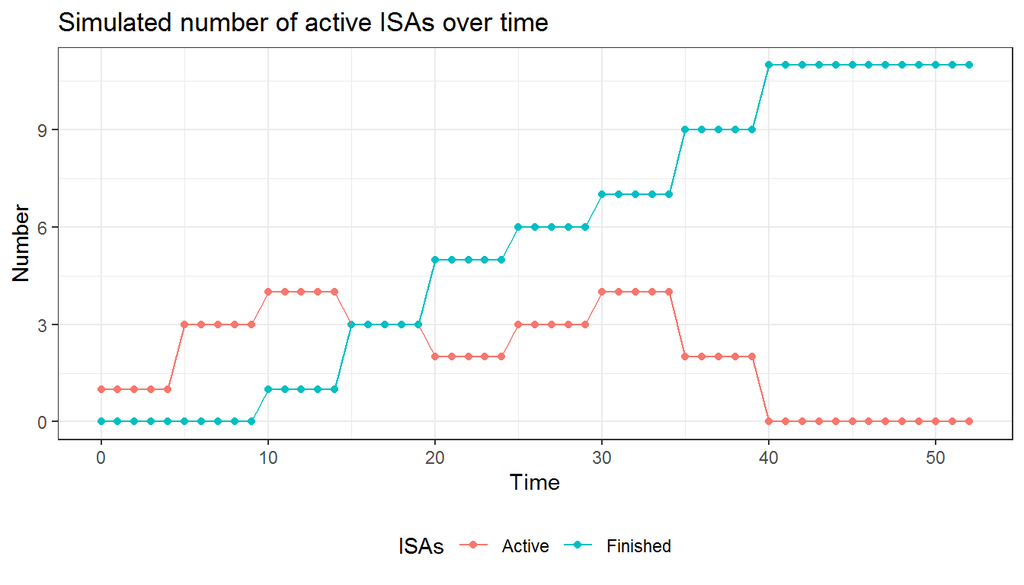

```r
x <- new_lIntrIncl(
  fnIntrIncl = function(lGlobVars, lAddArgs){
    if((lGlobVars$lVars$dCurrTime %% 5 == 0) & (length(lGlobVars$lVars$vIntrInclTimes) < lAddArgs$dIntrMax)){
      dAdd <- sample(c(1,2), 1)
    } else {
      dAdd <- 0
    }

  },

  lAddArgs = list(dIntrMax = 10)
)

plot(x)
```

**2. Let the entry of ISAs be random, with an entry probability of 0.2 at each time step, the maximum number of total ISAs be 6, the maximum number of parallel ISAs be 3 and the ISAs duration be 12.**

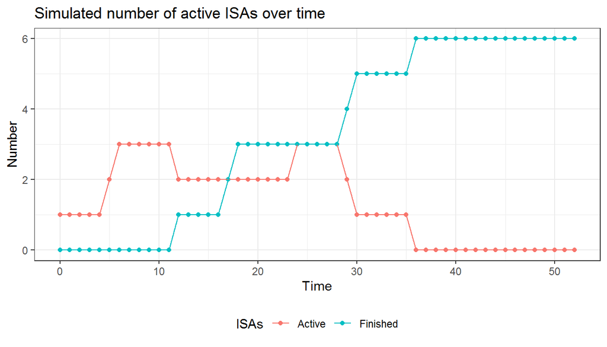

```r
x <- new_lIntrIncl(
  fnIntrIncl = function(lGlobVars, lAddArgs){
    if((length(lGlobVars$lVars$vIntrInclTimes) < lAddArgs$dIntrTotMax) & (lGlobVars$lVars$dActvIntr < lAddArgs$dIntrMax)){
      dAdd <- sample(c(1,0), 1, prob = c(lAddArgs$prob, 1-lAddArgs$prob))
    } else {
      dAdd <- 0
    }

    return(dAdd)
  },

  lAddArgs = list(dIntrMax = 3,
                  dIntrTotMax = 6,
                  prob = 0.2)
)


plot(x,
     intr_itt = "fixed",
     intr_itt_param = 12
     )
```

**3. Random entry (p = 0.2) and exit (p = 0.1) of ISAs be random with at every time step. Look at a period of 40 time units and prevent the addition of ISAs between time unit 10 and 20. No further restrictions concerning the number of ISAs**

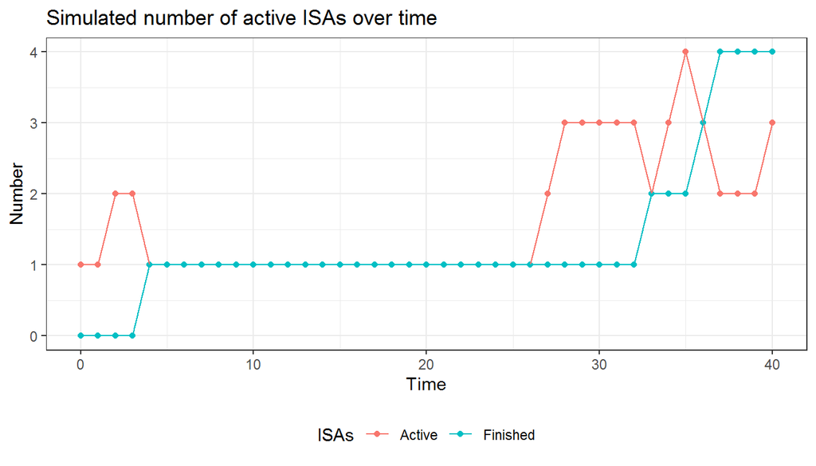

```r
x <- new_lIntrIncl(

  fnIntrIncl = function(lGlobVars, lAddArgs){
    if(lGlobVars$lVars$bInclAllowed){
      dAdd <- sample(c(1,0), 1, prob = c(lAddArgs$prob, 1-lAddArgs$prob))
    } else {
      dAdd <- 0
    }
      return(dAdd)
    },

  lAddArgs = list(prob = 0.2)

)

plot(x,
     intr_itt = "random",
     intr_itt_param = 0.1,
     dCurrTime = 1:40,
     bInclAllowed = c(rep(TRUE, 10), rep(FALSE, 10), rep(TRUE, 20)),
     )
```

### Remarks

Notice the different meanings of *lAddArgs$dIntrMax* in example one and two. In example 1 it specifies the total number of ISAs to be allowed in the trial whereas in example 2 it refers to the number of ISAs running in parallel. This should emphasize the flexibility of the module and show you, that the user has control over these variables and their names as well as the structure of the function.

The global variables saved in the list *lGlobVars* have a fixed name which can not be changed as it is implemented in many different modules. As mentioned above the vignette of the module *lGlobVars* will contain an overview of all the global variables used in any module. The naming convention consists of lowerCamelCase with the first part being a letter describing the data type of the object(l = list, b = bool, v = vector, d = number)